# COGS212 CourseProject - Exploratory Data Analysis (EDA)

2023-10-24

This project explores interrelated research questions: 1) how has internal migration within the United States changed over time? 2) when people do migrate internally, where do they migrate from and 3) where do they migrate to?

Load libraries:

```r
library(here)
library(skimr)
library(tidyr)
library(stringr)
library(dplyr)
```

```r
library(visdat)
library(ggplot2)
```

Read in data:

```r
df_raw <- read.csv(here("county_migration_data.csv"))
```

Check the packaging:

```r
skim(df_raw)
```

Data summary

| Name | df_raw |
| --- | --- |
| Number of rows | 164403 |
| Number of columns | 23 |
| _______________________ |  |
| Column type frequency: |  |
| numeric | 23 |
| ________________________ |  |
| Group variables | None |

**Variable type: numeric**

| skim_variable | n_missing | complete_rate | mean | sd | p0 | p25 | p50 | p75 | p100 | hist |
| --- | --- | --- | --- | --- | --- | --- | --- | --- | --- | --- |
| origin | 0 | 1 | 30018.29 | 18400.35 | 1001 | 13205 | 29075 | 42091 | 99999 | ▇▇▆▁▁ |
| destination | 0 | 1 | 30076.51 | 18588.02 | 1001 | 13121 | 29095 | 45013 | 99999 | ▇▇▆▁▁ |
| X1990 | 0 | 1 | 1240.23 | 28338.14 | -1 | 0 | 15 | 47 | 6489163 | ▇▁▁▁▁ |
| X1991 | 0 | 1 | 1254.05 | 28606.50 | -1 | 0 | 14 | 47 | 6515243 | ▇▁▁▁▁ |
| X1992 | 0 | 1 | 1259.70 | 28487.08 | 0 | 0 | 16 | 48 | 6437122 | ▇▁▁▁▁ |
| X1993 | 0 | 1 | 1261.76 | 28199.21 | 0 | 0 | 15 | 48 | 6246938 | ▇▁▁▁▁ |
| X1994 | 0 | 1 | 1262.44 | 27775.35 | 0 | 0 | 17 | 49 | 6010936 | ▇▁▁▁▁ |
| X1995 | 0 | 1 | 1276.65 | 28007.49 | 0 | 0 | 17 | 48 | 6005997 | ▇▁▁▁▁ |
| X1996 | 0 | 1 | 1293.89 | 28236.15 | 0 | 0 | 18 | 49 | 5986285 | ▇▁▁▁▁ |
| X1997 | 0 | 1 | 1307.48 | 28686.67 | 0 | 0 | 18 | 50 | 6135376 | ▇▁▁▁▁ |
| X1998 | 0 | 1 | 1330.69 | 29413.25 | 0 | 0 | 19 | 50 | 6376257 | ▇▁▁▁▁ |
| X1999 | 0 | 1 | 1356.60 | 30182.28 | 0 | 0 | 19 | 50 | 6588005 | ▇▁▁▁▁ |
| X2000 | 0 | 1 | 1372.24 | 30618.25 | 0 | 0 | 19 | 51 | 6696663 | ▇▁▁▁▁ |
| X2001 | 0 | 1 | 1387.53 | 31019.48 | 0 | 0 | 19 | 50 | 6780807 | ▇▁▁▁▁ |
| X2002 | 0 | 1 | 1400.78 | 31440.89 | 0 | 0 | 18 | 49 | 6901722 | ▇▁▁▁▁ |
| X2003 | 0 | 1 | 1411.99 | 31620.42 | 0 | 0 | 18 | 50 | 6936093 | ▇▁▁▁▁ |
| X2004 | 0 | 1 | 1418.73 | 31694.23 | 0 | 0 | 19 | 51 | 6932943 | ▇▁▁▁▁ |
| X2005 | 0 | 1 | 1421.49 | 31620.02 | 0 | 0 | 21 | 54 | 6876748 | ▇▁▁▁▁ |
| X2006 | 0 | 1 | 1433.68 | 31925.96 | 0 | 0 | 20 | 52 | 6887754 | ▇▁▁▁▁ |
| X2007 | 0 | 1 | 1484.31 | 33042.43 | 0 | 0 | 21 | 53 | 7084070 | ▇▁▁▁▁ |
| X2008 | 0 | 1 | 1509.15 | 33832.31 | 0 | 0 | 19 | 51 | 7241083 | ▇▁▁▁▁ |
| X2009 | 0 | 1 | 1502.67 | 33860.26 | 0 | 0 | 17 | 48 | 7215710 | ▇▁▁▁▁ |
| X2010 | 0 | 1 | 1507.73 | 34033.21 | 0 | 0 | 18 | 49 | 7244412 | ▇▁▁▁▁ |

Each column is a year of data. Therefore, I need to turn the data frame from a wide format to a long format.

First, I need to rename the columns:

```r
colnames(df_raw)
```

```
##  [1] "origin"      "destination" "X1990"       "X1991"       "X1992"
##  [6] "X1993"       "X1994"       "X1995"       "X1996"       "X1997"
## [11] "X1998"       "X1999"       "X2000"       "X2001"       "X2002"
## [16] "X2003"       "X2004"       "X2005"       "X2006"       "X2007"
## [21] "X2008"       "X2009"       "X2010"
```

```r
colnames(df_raw) <- c("origin", "destination", as.character(1990:2010))
colnames(df_raw)
```

```
##  [1] "origin"      "destination" "1990"        "1991"        "1992"
##  [6] "1993"        "1994"        "1995"        "1996"        "1997"
## [11] "1998"        "1999"        "2000"        "2001"        "2002"
## [16] "2003"        "2004"        "2005"        "2006"        "2007"
## [21] "2008"        "2009"        "2010"
```

I can now transform the dataset from a wide format to a long format:

```r
df_long <- gather(df_raw, year, migrants, "1990":"2010", factor_key=TRUE)
```

As a quick check:

```r
21 * 164403
```

```
## [1] 3452463
```

Looks like the transformation worked! (Note: 21 is the number of years and 164403 is the number of rows in the original dataset.)

Look at the top of the dataset:

```r
head(df_long)
```

```
##   origin destination year migrants
## 1   1001        1001 1990    26703
## 2   1001        1003 1990        0
## 3   1001        1013 1990        0
## 4   1001        1021 1990      101
## 5   1001        1041 1990        0
## 6   1001        1047 1990       68
```

Look at the bottom of the dataset:

```r
tail(df_long)
```

```
##         origin destination year migrants
## 3452458  99999       56035 2010      643
## 3452459  99999       56037 2010     1750
## 3452460  99999       56039 2010      987
## 3452461  99999       56041 2010      680
## 3452462  99999       56043 2010      311
## 3452463  99999       56045 2010      291
```

This dataset only provides the FIPS codes for the counties. In this project, I am going to focus on between state-level rather than county-level migration. The first two numbers indicate the state; therefore, I can use these codes to determine the origin state and destination state. More information on the FIPS codes can be found here: https://transition.fcc.gov/oet/info/maps/census/fips/fips.txt. To do this, I need to 1) add a zero at the beginning of the FIPS code for codes with only four numbers, 2) separate the first two numbers from the remainder of the FIPS code, 3) create a key that matches FIPS code to state name, and 4) merge this key with my data frame.

Step 1: Add zeros

```r
df_long$origin_new <- ifelse(nchar(df_long$origin) < 5, paste("0", df_long$origin, sep = ""), df_long$origin)

df_long$destination_new <- ifelse(nchar(df_long$destination) < 5, paste("0", df_long$destination, sep = ""), df_long$destination)
```

Step 2: Separate first two numbers

```r
df_long$origin_state_num <- str_extract(df_long$origin_new, "^\\d{2}")
df_long$destination_state_num <- str_extract(df_long$destination_new, "^\\d{2}")
```

Check that these columns look correct - values should be between 01 and 56

```r
unique(df_long$origin_state_num)
```

```
##  [1] "01" "02" "04" "05" "06" "08" "09" "10" "11" "12" "13" "15" "16" "17" "18"
## [16] "19" "20" "21" "22" "23" "24" "25" "26" "27" "28" "29" "30" "31" "32" "33"
## [31] "34" "35" "36" "37" "38" "39" "40" "41" "42" "44" "45" "46" "47" "48" "49"
## [46] "50" "51" "53" "54" "55" "56" "99"
```

```r
unique(df_long$destination_state_num)
```

```
##  [1] "01" "08" "12" "13" "15" "17" "28" "32" "37" "45" "48" "51" "99" "04" "06"
## [16] "22" "26" "34" "36" "47" "53" "02" "20" "21" "24" "29" "40" "35" "05" "09"
## [31] "10" "11" "18" "25" "27" "31" "39" "41" "42" "49" "55" "19" "16" "23" "30"
## [46] "33" "38" "46" "56" "44" "50" "54"
```

The 99 values are missing values (it is unknown where people came from or went)! I’m going to do a check check of how many observations are missing (as a percentage of the data frame):

```r
(sum(df_long$origin_state_num == "99")/nrow(df_long)) * 100
```

```
## [1] 1.916023
```

```r
(sum(df_long$destination_state_num == "99")/nrow(df_long)) * 100
```

```
## [1] 1.916023
```

It is about 2% of each variable. I am going to remove those now, as to ensure this does not create a problem when I try merging my key onto this data set:

```r
df_long_sub <- subset(df_long, origin_state_num != "99")
sum(df_long_sub$origin_state_num == "99")
```

```
## [1] 0
```

```r
df_long_sub <- subset(df_long_sub, destination_state_num != "99")
sum(df_long_sub$destination_state_num == "99")
```

```
## [1] 0
```

Step 3: Create key (Note: I am creating this key based on the documentation linked above.)

```r
FIPS <- c("01", "02", "04", "05", "06", "08", "09", as.character(10:13),
          as.character(15:42), as.character(44:51), as.character(53:56))
Statename <- c("Alabama", "Alaska", "Arizona", "Arkansas", "California", "Colorado",
               "Connecticut", "Delaware", "District of Columbia", "Florida",
               "Georgia", "Hawaii", "Idaho", "Illinois", "Indiana", "Iowa",
               "Kansas", "Kentucky", "Louisiana", "Maine", "Maryland",
               "Massachusetts", "Michigan", "Minnesota", "Mississippi", "Missouri",
               "Montana", "Nebraska", "Nevada", "New Hampshire", "New Jersey",
               "New Mexico", "New York", "North Carolina", "North Dakota", "Ohio",
               "Oklahoma", "Oregon", "Pennsylvania", "Rhode Island", "South Carolina",
               "South Dakota", "Tennessee", "Texas", "Utah", "Vermont", "Virginia",
               "Washington", "West Virginia", "Wisconsin", "Wyoming")

key <- data.frame(FIPS, Statename)

key
```

```
##    FIPS            Statename
## 1    01              Alabama
## 2    02               Alaska
## 3    04              Arizona
## 4    05             Arkansas
## 5    06           California
## 6    08             Colorado
## 7    09          Connecticut
## 8    10             Delaware
## 9    11 District of Columbia
## 10   12              Florida
## 11   13              Georgia
## 12   15               Hawaii
## 13   16                Idaho
## 14   17             Illinois
```

[output cut: 37 more lines]

Step 4: Merge key with data First merge onto origin:

```r
colnames(key) <- c("origin_state_num", "origin_state_name")
df_state <- plyr::join(df_long_sub, key, by = c("origin_state_num"))
```

Then merge onto destination:

```r
colnames(key) <- c("destination_state_num", "destination_state_name")
df_state <- plyr::join(df_state, key, by = c("destination_state_num"))
```

I am now going to subset to only the columns that I need for my analysis:

```r
df_state <- subset(df_state, select = c(origin_state_num, origin_state_name, destination_state_num, destination_state_name, year, migrants))
```

Check my “n’s” Year:

```r
df_state |>
    count(year)
```

```
##    year      n
## 1  1990 158103
## 2  1991 158103
## 3  1992 158103
## 4  1993 158103
## 5  1994 158103
## 6  1995 158103
## 7  1996 158103
## 8  1997 158103
## 9  1998 158103
## 10 1999 158103
## 11 2000 158103
## 12 2001 158103
## 13 2002 158103
## 14 2003 158103
## 15 2004 158103
## 16 2005 158103
## 17 2006 158103
## 18 2007 158103
## 19 2008 158103
## 20 2009 158103
## 21 2010 158103
```

Origin state:

```r
df_state |>
    count(origin_state_name)
```

```
##       origin_state_name      n
## 1               Alabama  56952
## 2                Alaska  17766
## 3               Arizona  48300
## 4              Arkansas  40992
## 5            California 218148
## 6              Colorado  77679
## 7           Connecticut  34986
## 8              Delaware   9870
## 9  District of Columbia   6930
## 10              Florida 232596
## 11              Georgia 137067
## 12               Hawaii  15540
## 13                Idaho  23415
## 14             Illinois 108633
```

[output cut: 37 more lines]

Destination state:

```r
df_state |>
    count(destination_state_name)
```

```
##    destination_state_name      n
## 1                 Alabama  61593
## 2                  Alaska  17283
## 3                 Arizona  57813
## 4                Arkansas  43869
## 5              California 186942
## 6                Colorado  91875
## 7             Connecticut  26103
## 8                Delaware  10962
## 9    District of Columbia   8736
## 10                Florida 267120
## 11                Georgia 156975
## 12                 Hawaii  15477
## 13                  Idaho  26502
## 14               Illinois  94248
```

[output cut: 37 more lines]

We can see that not all states have the same number of observations. This is because the data still reflects the county-level data, NOT state-level. I need to summarize the data by year and state-dyad:

```r
df_state_agg <- df_state |>
  group_by(origin_state_name, origin_state_num, destination_state_name, destination_state_num, year) |>
  summarize(migrants = sum(migrants, na.rm = TRUE))
```

[output not shown]

Let’s look at the n’s now:

```r
df_state_agg |>
    count(origin_state_name)
```

```
## # A tibble: 2,391 × 5
## # Groups:   origin_state_name, origin_state_num, destination_state_name,
## #   destination_state_num [2,391]
##    origin_state_name origin_state_num destination_state_name
##    <chr>             <chr>            <chr>
##  1 Alabama           01               Alabama
##  2 Alabama           01               Alaska
##  3 Alabama           01               Arizona
##  4 Alabama           01               Arkansas
##  5 Alabama           01               California
##  6 Alabama           01               Colorado
##  7 Alabama           01               Connecticut
##  8 Alabama           01               Delaware
##  9 Alabama           01               District of Columbia
## 10 Alabama           01               Florida
## # ℹ 2,381 more rows
## # ℹ 2 more variables: destination_state_num <chr>, n <int>
```

```r
df_state_agg |>
    count(destination_state_name)
```

```
## # A tibble: 2,391 × 5
## # Groups:   origin_state_name, origin_state_num, destination_state_name,
## #   destination_state_num [2,391]
##    origin_state_name origin_state_num destination_state_name
##    <chr>             <chr>            <chr>
##  1 Alabama           01               Alabama
##  2 Alabama           01               Alaska
##  3 Alabama           01               Arizona
##  4 Alabama           01               Arkansas
##  5 Alabama           01               California
##  6 Alabama           01               Colorado
##  7 Alabama           01               Connecticut
##  8 Alabama           01               Delaware
##  9 Alabama           01               District of Columbia
## 10 Alabama           01               Florida
## # ℹ 2,381 more rows
## # ℹ 2 more variables: destination_state_num <chr>, n <int>
```

Looks good now!

I am going to double check that I have no missingness in my data set:

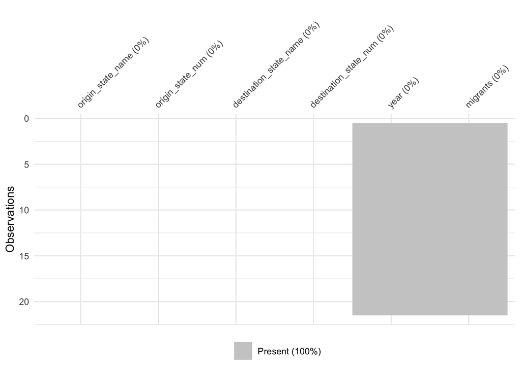

```r
vis_miss(df_state_agg)
```

I am going to create the following variables that will be useful to answering my research questions: 1) total migrants that year, 2) total migrants from a given origin state, and 3) total migrants to a given destination state.

```r
df_state_agg <- df_state_agg |>
  group_by(year) |>
  mutate(migrants_year = sum(migrants, na.rm = TRUE))

df_state_agg <- df_state_agg |>
  group_by(origin_state_name) |>
  mutate(migrants_origin = sum(migrants, na.rm = TRUE))

df_state_agg <- df_state_agg |>
  group_by(destination_state_name) |>
  mutate(migrants_destination = sum(migrants, na.rm = TRUE))
```

Before I start plotting, I need to remove sceientific notation:

```r
options(scipen=999)
```

I am now going to look at the general distribution of the migrant variable:

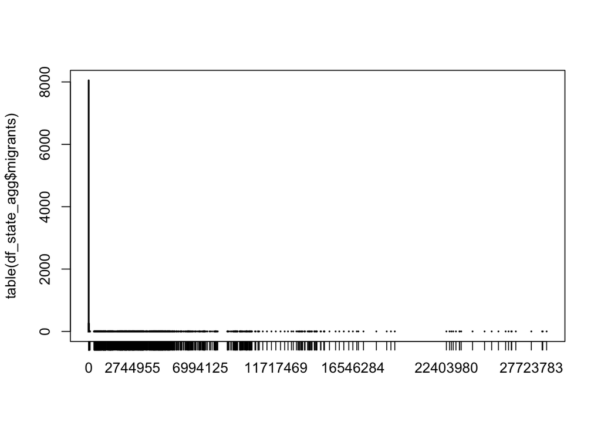

```r
plot(table(df_state_agg$migrants))
```

This plot looks at how the number of migrants has changed over time:

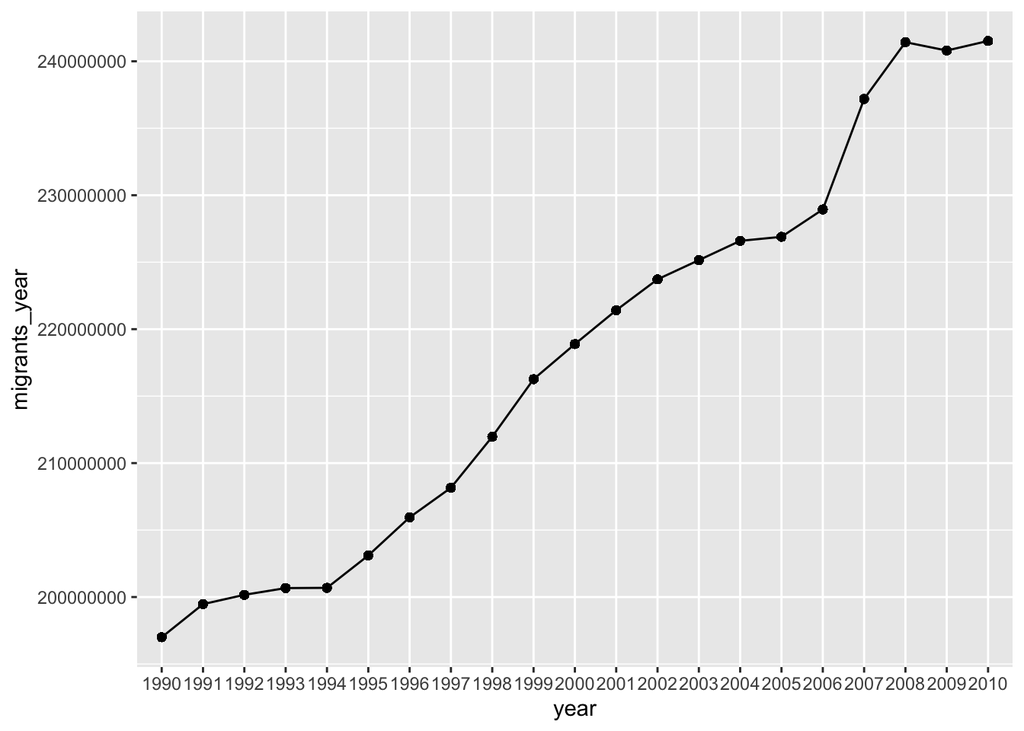

```r
ggplot(df_state_agg, aes(x = year, y = migrants_year, group = 1)) +
  geom_line()+
  geom_point()
```

Creating tables of migrants by destination and origin state:

```r
destination <- subset(df_state_agg, select = c(destination_state_name, migrants_destination))
destination <- destination %>%
  group_by(destination_state_name) %>%
  summarize(migrants_destination = sum(migrants_destination, na.rm = TRUE))

origin <- subset(df_state_agg, select = c(origin_state_name, migrants_origin))
origin <- origin %>%
  group_by(origin_state_name) %>%
  summarize(migrants_origin = sum(migrants_origin, na.rm = TRUE))
```

This is a bar plot of all destination states…:

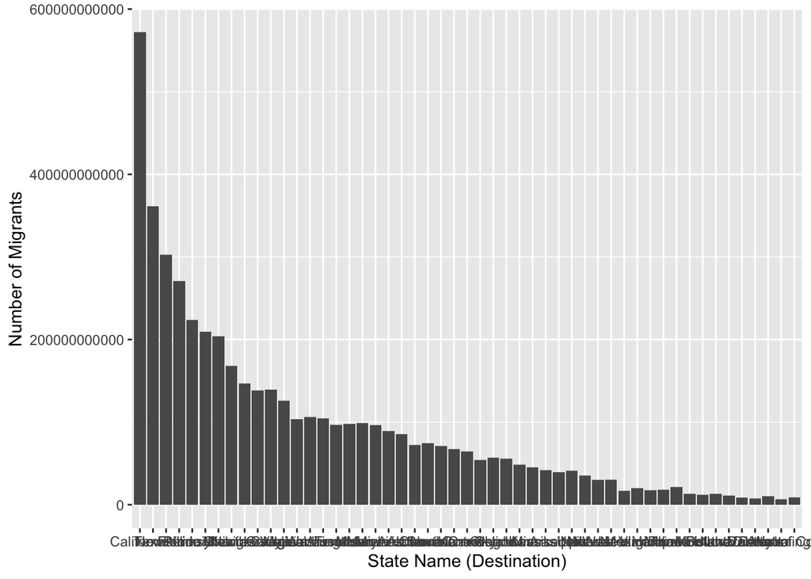

```r
ggplot(df_state_agg, aes(x=reorder(destination_state_name, -migrants_destination), y=migrants_destination)) +
  geom_bar(stat = "identity") +
  labs(x = "State Name (Destination)", y = "Number of Migrants")
```

…and of top 10 destination states:

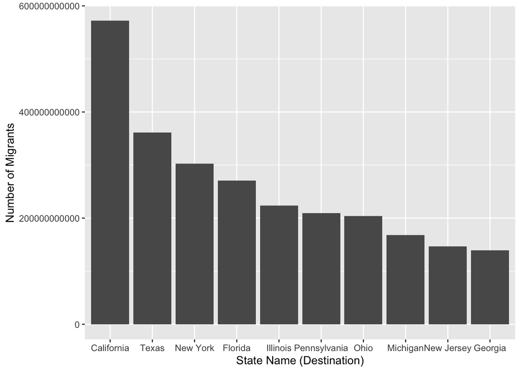

```r
destination_10 <- subset(df_state_agg, destination_state_name %in% c("California", "Texas", "New York", "Florida", "Illinois", "Pennsylvania", "Ohio", "Michigan", "New Jersey", "Georgia"))

ggplot(destination_10, aes(x=reorder(destination_state_name, -migrants_destination), y=migrants_destination)) +
  geom_bar(stat = "identity") +
  labs(x = "State Name (Destination)", y = "Number of Migrants")
```

This is a bar plot of all origin states…:

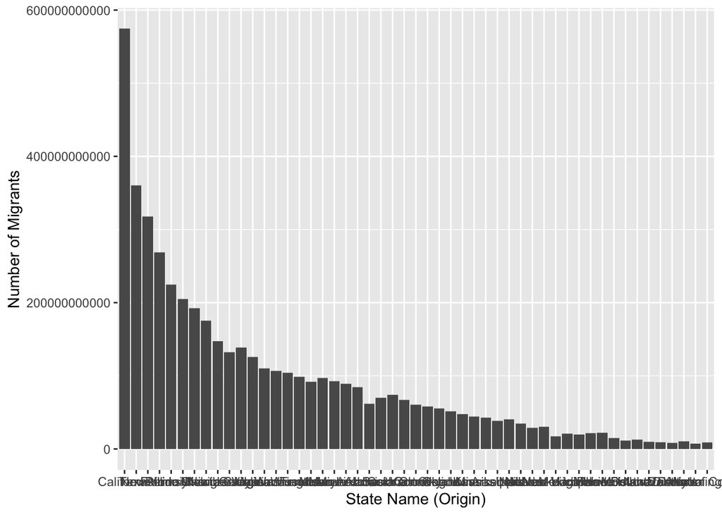

```r
ggplot(df_state_agg, aes(x=reorder(origin_state_name, -migrants_origin), y=migrants_origin)) +
  geom_bar(stat = "identity") +
  labs(x = "State Name (Origin)", y = "Number of Migrants")
```

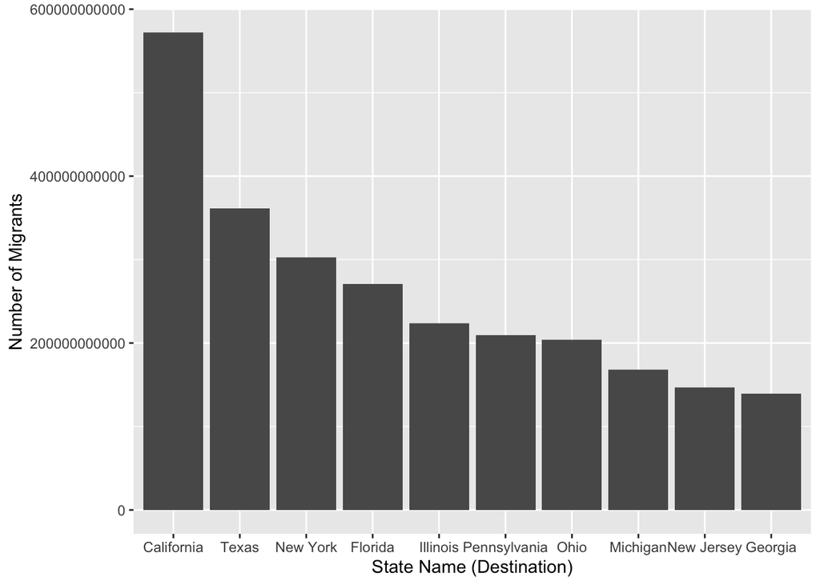

```r
origin_10 <- subset(df_state_agg, origin_state_name %in% c("California", "Texas", "New York", "Florida", "Illinois", "Pennsylvania", "Ohio", "Michigan", "New Jersey", "Georgia"))

ggplot(destination_10, aes(x=reorder(destination_state_name, -migrants_destination), y=migrants_destination)) +
  geom_bar(stat = "identity") +
  labs(x = "State Name (Destination)", y = "Number of Migrants")
```